# Weight sensitivity

## Table 1. Weight misspecification (non-null GWAS)

Per-replicate percentage change in *r*<sup>2</sup> with the true genetic value when PRS-LDmix uses a weight off from w<sub>0</sub> by the column offset, relative to PRS-LDmix at w<sub>0</sub>; negative values mean lower accuracy. The change is relative, *r*<sup>2</sup>(w)/*r*<sup>2</sup>(w<sub>0</sub>) − 1 per replicate, so the threshold is a fraction of the generating-weight *r*<sup>2</sup>, not an absolute difference. Bold: the lower 95% bound falls below −2%, the acceptable relative loss fixed before the curves were examined; unbolded cells are within it. –: the weight is outside [0, 1]. Exploratory analysis, not curated paper evidence. Chromosome 22, fixed 250 kb LD blocks, PRS-CS with automatic φ and default sampler settings. Replicates per setting (the first 100 available): 100 for EUR + ASN 90:10, EUR + ASN 70:30, EUR + ASN 50:50, EUR + SAS 90:10, EUR + SAS 70:30, EUR + SAS 50:50, EUR + AFR 90:10, EUR + AFR 70:30, EUR + AFR 50:50, ASN + AFR 90:10, ASN + AFR 70:30, ASN + AFR 50:50. w<sub>0</sub> is the generating weight on the first-listed ancestry; PRS-LDmix at w = 1 and 0 is first- and second-ancestry PRS-CS. Square brackets are pointwise 95% t intervals over replicates, paired within replicate; they are exploratory and not adjusted for the number of settings and weights.

| Pair | GWAS mix | Targets | Relative *r*<sup>2</sup> change (%) when the weight is off by -0.2 | Relative *r*<sup>2</sup> change (%) when the weight is off by -0.1 | Relative *r*<sup>2</sup> change (%) when the weight is off by +0.1 | Relative *r*<sup>2</sup> change (%) when the weight is off by +0.2 |
| --- | --- | --- | --- | --- | --- | --- |
| EUR + ASN | 90:10 | EUR | −0.8 [−1.0, −0.5] | −0.3 [−0.5, −0.1] | +0.2 [0.0, +0.5] | – |
|  |  | ASN | −0.8 [−1.1, −0.4] | −0.1 [−0.4, +0.2] | +0.6 [+0.2, +0.9] | – |
|  | 70:30 | EUR | −0.5 [−0.8, −0.3] | −0.1 [−0.3, +0.1] | +0.1 [−0.1, +0.3] | +0.1 [−0.2, +0.4] |
|  |  | ASN | −0.7 [−1.0, −0.3] | −0.2 [−0.4, +0.1] | +0.2 [−0.1, +0.5] | +0.2 [−0.1, +0.5] |
|  | 50:50 | EUR | −0.3 [−0.6, +0.1] | −0.1 [−0.4, +0.2] | 0.0 [−0.3, +0.2] | 0.0 [−0.3, +0.3] |
|  |  | ASN | −0.4 [−0.7, −0.1] | 0.0 [−0.3, +0.3] | +0.1 [−0.1, +0.4] | 0.0 [−0.3, +0.3] |
| EUR + SAS | 90:10 | EUR | −0.3 [−0.5, 0.0] | −0.2 [−0.4, +0.1] | +0.1 [−0.2, +0.3] | – |
|  |  | SAS | −0.3 [−0.9, +0.4] | −0.1 [−0.8, +0.5] | +0.3 [−0.3, +1.0] | – |
|  | 70:30 | EUR | +0.5 [+0.3, +0.7] | +0.4 [+0.2, +0.6] | −0.3 [−0.5, −0.1] | −0.6 [−0.8, −0.4] |
|  |  | SAS | +0.7 [0.0, +1.3] | +0.8 [+0.1, +1.6] | +0.1 [−0.6, +0.7] | −0.4 [−1.1, +0.4] |
|  | 50:50 | EUR | +1.3 [+1.1, +1.5] | +0.7 [+0.5, +0.9] | −1.0 [−1.2, −0.8] | **−2.1 [−2.3, −1.8]** |
|  |  | SAS | +1.8 [+1.1, +2.6] | +1.3 [+0.5, +2.0] | **−1.4 [−2.2, −0.7]** | **−2.8 [−3.7, −2.0]** |
| EUR + AFR | 90:10 | EUR | −0.6 [−0.9, −0.4] | −0.1 [−0.3, +0.2] | +0.2 [−0.1, +0.4] | – |
|  |  | AFR | +1.1 [+0.1, +2.0] | +1.6 [+0.6, +2.7] | −0.5 [−1.5, +0.6] | – |
|  | 70:30 | EUR | +1.8 [+1.3, +2.3] | +1.2 [+0.9, +1.5] | −1.4 [−1.8, −1.1] | **−3.6 [−4.3, −2.9]** |
|  |  | AFR | +9.7 [+7.6, +11.7] | +5.3 [+4.2, +6.4] | **−4.4 [−5.6, −3.1]** | **−11.8 [−13.8, −9.9]** |
|  | 50:50 | EUR | +5.0 [+4.5, +5.5] | +2.6 [+2.3, +3.0] | **−3.2 [−3.5, −2.8]** | **−7.2 [−7.8, −6.5]** |
|  |  | AFR | +29.0 [−0.8, +58.7] | +6.0 [+3.1, +9.0] | **−0.1 [−11.5, +11.3]** | **+21.6 [−40.7, +83.9]** |
| ASN + AFR | 90:10 | ASN | −0.8 [−1.1, −0.5] | −0.5 [−0.7, −0.2] | 0.0 [−0.2, +0.2] | – |
|  |  | AFR | +0.3 [−0.7, +1.2] | +0.3 [−0.5, +1.1] | 0.0 [−1.0, +1.1] | – |
|  | 70:30 | ASN | +2.0 [+1.5, +2.5] | +1.1 [+0.7, +1.4] | −1.6 [−2.0, −1.2] | **−4.2 [−4.9, −3.5]** |
|  |  | AFR | +6.1 [+5.0, +7.2] | +3.7 [+2.8, +4.6] | **−4.3 [−5.2, −3.4]** | **−9.7 [−10.9, −8.4]** |
|  | 50:50 | ASN | +5.5 [+4.9, +6.1] | +2.8 [+2.5, +3.2] | **−3.4 [−3.6, −3.1]** | **−7.4 [−7.9, −6.9]** |
|  |  | AFR | +9.5 [+7.8, +11.3] | +4.9 [+3.8, +5.9] | **−5.1 [−6.0, −4.3]** | **−10.9 [−12.6, −9.2]** |

## Table 2. PRS-LDmix at the generating weight against the single panels (non-null GWAS)

Paired differences in *r*<sup>2</sup> (positive favours PRS-LDmix) and geometric-mean percentage change in mean squared error against the true genetic value (negative favours PRS-LDmix). Exploratory analysis, not curated paper evidence. Chromosome 22, fixed 250 kb LD blocks, PRS-CS with automatic φ and default sampler settings. Replicates per setting (the first 100 available): 100 for EUR + ASN 90:10, EUR + ASN 70:30, EUR + ASN 50:50, EUR + SAS 90:10, EUR + SAS 70:30, EUR + SAS 50:50, EUR + AFR 90:10, EUR + AFR 70:30, EUR + AFR 50:50, ASN + AFR 90:10, ASN + AFR 70:30, ASN + AFR 50:50. w<sub>0</sub> is the generating weight on the first-listed ancestry; PRS-LDmix at w = 1 and 0 is first- and second-ancestry PRS-CS. Square brackets are pointwise 95% t intervals over replicates, paired within replicate; they are exploratory and not adjusted for the number of settings and weights.

| Pair | GWAS mix | Targets | PRS-LDmix minus first-ancestry PRS-CS *r*<sup>2</sup> | PRS-LDmix minus first-ancestry PRS-CS MSE (%) | PRS-LDmix minus second-ancestry PRS-CS *r*<sup>2</sup> | PRS-LDmix minus second-ancestry PRS-CS MSE (%) |
| --- | --- | --- | --- | --- | --- | --- |
| EUR + ASN | 90:10 | EUR | −0.0011 [−0.0025, +0.0003] | +0.8 [+0.3, +1.4] | +0.0768 [+0.0694, +0.0841] | −54.7 [−57.7, −51.5] |
|  |  | ASN | −0.0031 [−0.0049, −0.0012] | +0.5 [0.0, +1.0] | +0.0629 [+0.0583, +0.0674] | −21.7 [−23.4, −20.0] |
|  | 70:30 | EUR | +0.0003 [−0.0016, +0.0022] | +0.3 [−0.3, +1.0] | +0.0412 [+0.0356, +0.0469] | −28.9 [−32.5, −25.2] |
|  |  | ASN | −0.0004 [−0.0029, +0.0020] | −1.1 [−1.9, −0.4] | +0.0323 [+0.0286, +0.0359] | −10.8 [−12.3, −9.3] |
|  | 50:50 | EUR | +0.0073 [+0.0046, +0.0099] | −2.4 [−3.4, −1.5] | +0.0141 [+0.0106, +0.0176] | −9.6 [−11.7, −7.6] |
|  |  | ASN | +0.0138 [+0.0081, +0.0195] | −10.0 [−13.0, −6.8] | +0.0120 [+0.0093, +0.0147] | −3.7 [−4.7, −2.7] |
| EUR + SAS | 90:10 | EUR | −0.0003 [−0.0015, +0.0009] | +0.6 [+0.1, +1.0] | +0.0192 [+0.0163, +0.0220] | −22.8 [−24.5, −21.0] |
|  |  | SAS | −0.0017 [−0.0048, +0.0013] | +0.6 [−0.2, +1.3] | +0.0253 [+0.0205, +0.0301] | −13.3 [−14.8, −11.8] |
|  | 70:30 | EUR | +0.0055 [+0.0044, +0.0066] | −1.9 [−2.5, −1.3] | +0.0024 [+0.0007, +0.0041] | −21.7 [−22.7, −20.8] |
|  |  | SAS | +0.0076 [+0.0049, +0.0103] | −7.1 [−8.0, −6.2] | +0.0044 [+0.0009, +0.0079] | −11.1 [−12.2, −10.0] |
|  | 50:50 | EUR | +0.0172 [+0.0162, +0.0182] | −9.0 [−9.4, −8.6] | −0.0047 [−0.0058, −0.0036] | −20.1 [−20.6, −19.7] |
|  |  | SAS | +0.0206 [+0.0176, +0.0236] | −29.5 [−30.4, −28.5] | −0.0044 [−0.0069, −0.0019] | −5.2 [−6.1, −4.4] |
| EUR + AFR | 90:10 | EUR | −0.0008 [−0.0021, +0.0005] | +1.4 [+0.9, +1.9] | +0.0509 [+0.0454, +0.0564] | −66.5 [−68.7, −64.1] |
|  |  | AFR | +0.0013 [−0.0023, +0.0049] | −1.6 [−2.8, −0.3] | +0.0360 [+0.0260, +0.0459] | −32.0 [−34.2, −29.7] |
|  | 70:30 | EUR | +0.0290 [+0.0243, +0.0336] | −11.2 [−13.8, −8.5] | +0.0012 [−0.0044, +0.0068] | −52.3 [−54.4, −50.1] |
|  |  | AFR | +0.0276 [+0.0246, +0.0306] | −47.1 [−51.4, −42.4] | −0.0230 [−0.0285, −0.0174] | +10.5 [+3.4, +18.1] |
|  | 50:50 | EUR | +0.0750 [+0.0708, +0.0792] | −33.2 [−35.7, −30.5] | −0.0249 [−0.0277, −0.0222] | −40.1 [−41.4, −38.8] |
|  |  | AFR | +0.0343 [+0.0284, +0.0402] | −83.4 [−84.5, −82.3] | −0.0230 [−0.0257, −0.0202] | +45.8 [+39.2, +52.8] |
| ASN + AFR | 90:10 | ASN | +0.0002 [−0.0011, +0.0014] | +1.4 [+1.0, +1.9] | +0.0820 [+0.0750, +0.0890] | −79.7 [−81.1, −78.1] |
|  |  | AFR | +0.0005 [−0.0032, +0.0042] | −2.2 [−3.5, −0.9] | +0.0526 [+0.0424, +0.0628] | −40.8 [−43.1, −38.4] |
|  | 70:30 | ASN | +0.0343 [+0.0298, +0.0388] | −11.8 [−14.1, −9.4] | +0.0119 [+0.0045, +0.0193] | −62.9 [−64.8, −60.9] |
|  |  | AFR | +0.0309 [+0.0278, +0.0339] | −53.9 [−58.0, −49.5] | −0.0164 [−0.0224, −0.0104] | +8.1 [+0.4, +16.5] |
|  | 50:50 | ASN | +0.0781 [+0.0751, +0.0812] | −30.2 [−31.8, −28.4] | −0.0289 [−0.0325, −0.0253] | −45.5 [−46.7, −44.2] |
|  |  | AFR | +0.0326 [+0.0281, +0.0371] | −84.9 [−85.8, −83.9] | −0.0215 [−0.0240, −0.0190] | +46.8 [+40.2, +53.7] |

## Table 3. Recovery of the composition by null LD fit

Per replicate, the weight in 0, 0.1, …, 1 that minimises the Gaussian LD-fit loss (ridge 0.001) of the mixed panel against the null GWAS z-scores; mean (Monte Carlo SE) over replicates. The null GWAS is simulated separately from the non-null GWAS in Tables 1, 2 and 4, so this asks only whether LD fit recovers the composition; it does not validate LD fit as a way to choose the weight for prediction. Exploratory analysis, not curated paper evidence. Chromosome 22, fixed 250 kb LD blocks, PRS-CS with automatic φ and default sampler settings. Replicates per setting (the first 100 available): 100 for EUR + ASN 90:10, EUR + ASN 70:30, EUR + ASN 50:50, EUR + SAS 90:10, EUR + SAS 70:30, EUR + SAS 50:50, EUR + AFR 90:10, EUR + AFR 70:30, EUR + AFR 50:50, ASN + AFR 90:10, ASN + AFR 70:30, ASN + AFR 50:50. w<sub>0</sub> is the generating weight on the first-listed ancestry; PRS-LDmix at w = 1 and 0 is first- and second-ancestry PRS-CS. Square brackets are pointwise 95% t intervals over replicates, paired within replicate; they are exploratory and not adjusted for the number of settings and weights.

| Pair | GWAS mix | Weight minimising null LD-fit loss, per replicate Mean (SE) | Weight minimising null LD-fit loss, per replicate Mean absolute error | Weight minimising null LD-fit loss, per replicate Exactly w<sub>0</sub> (%) | Weight minimising null LD-fit loss, per replicate Within ±0.1 (%) |
| --- | --- | --- | --- | --- | --- |
| EUR + ASN | 90:10 | 0.90 (0.00) | 0.00 | 100 | 100 |
|  | 70:30 | 0.70 (0.00) | 0.00 | 99 | 100 |
|  | 50:50 | 0.51 (0.00) | 0.00 | 95 | 100 |
| EUR + SAS | 90:10 | 0.90 (0.00) | 0.00 | 100 | 100 |
|  | 70:30 | 0.76 (0.00) | 0.06 | 39 | 100 |
|  | 50:50 | 0.63 (0.00) | 0.13 | 0 | 67 |
| EUR + AFR | 90:10 | 0.90 (0.00) | 0.00 | 100 | 100 |
|  | 70:30 | 0.70 (0.00) | 0.01 | 92 | 100 |
|  | 50:50 | 0.51 (0.00) | 0.01 | 85 | 100 |
| ASN + AFR | 90:10 | 0.90 (0.00) | 0.00 | 100 | 100 |
|  | 70:30 | 0.70 (0.00) | 0.00 | 97 | 100 |
|  | 50:50 | 0.51 (0.00) | 0.01 | 87 | 100 |

## Table 4. Oracle benchmarks (retrospective)

The weight with the highest mean *r*<sup>2</sup>, and the better of the two single panels, both chosen with the true genetic values of the same target individuals; mean (Monte Carlo SE). These choices are not available to a user and are optimistic by construction; they show how much a perfectly informed choice could gain over the generating weight. Exploratory analysis, not curated paper evidence. Chromosome 22, fixed 250 kb LD blocks, PRS-CS with automatic φ and default sampler settings. Replicates per setting (the first 100 available): 100 for EUR + ASN 90:10, EUR + ASN 70:30, EUR + ASN 50:50, EUR + SAS 90:10, EUR + SAS 70:30, EUR + SAS 50:50, EUR + AFR 90:10, EUR + AFR 70:30, EUR + AFR 50:50, ASN + AFR 90:10, ASN + AFR 70:30, ASN + AFR 50:50. w<sub>0</sub> is the generating weight on the first-listed ancestry; PRS-LDmix at w = 1 and 0 is first- and second-ancestry PRS-CS. Square brackets are pointwise 95% t intervals over replicates, paired within replicate; they are exploratory and not adjusted for the number of settings and weights.

| Pair | GWAS mix | Targets | PRS-LDmix at w<sub>0</sub> *r*<sup>2</sup> | Best weight (oracle) Weight | Best weight (oracle) *r*<sup>2</sup> | Better single panel (oracle) Panel | Better single panel (oracle) *r*<sup>2</sup> |
| --- | --- | --- | --- | --- | --- | --- | --- |
| EUR + ASN | 90:10 | EUR | 0.573 (0.005) | 1.0 | 0.575 (0.005) | EUR | 0.575 (0.005) |
|  |  | ASN | 0.548 (0.005) | 1.0 | 0.551 (0.005) | EUR | 0.551 (0.005) |
|  | 70:30 | EUR | 0.591 (0.005) | 0.8 | 0.592 (0.005) | EUR | 0.591 (0.005) |
|  |  | ASN | 0.582 (0.005) | 0.8 | 0.583 (0.005) | EUR | 0.582 (0.005) |
|  | 50:50 | EUR | 0.593 (0.005) | 0.5 | 0.593 (0.005) | EUR | 0.586 (0.005) |
|  |  | ASN | 0.593 (0.005) | 0.6 | 0.594 (0.005) | ASN | 0.581 (0.005) |
| EUR + SAS | 90:10 | EUR | 0.535 (0.005) | 1.0 | 0.535 (0.005) | EUR | 0.535 (0.005) |
|  |  | SAS | 0.515 (0.008) | 1.0 | 0.516 (0.008) | EUR | 0.516 (0.008) |
|  | 70:30 | EUR | 0.416 (0.004) | 0.4 | 0.418 (0.004) | SAS | 0.413 (0.004) |
|  |  | SAS | 0.375 (0.008) | 0.6 | 0.378 (0.008) | SAS | 0.371 (0.008) |
|  | 50:50 | EUR | 0.241 (0.003) | 0.1 | 0.246 (0.003) | SAS | 0.246 (0.003) |
|  |  | SAS | 0.198 (0.007) | 0.0 | 0.203 (0.007) | SAS | 0.203 (0.007) |
| EUR + AFR | 90:10 | EUR | 0.543 (0.005) | 1.0 | 0.544 (0.005) | EUR | 0.544 (0.005) |
|  |  | AFR | 0.382 (0.011) | 0.8 | 0.386 (0.010) | EUR | 0.380 (0.011) |
|  | 70:30 | EUR | 0.443 (0.006) | 0.3 | 0.452 (0.005) | AFR | 0.442 (0.005) |
|  |  | AFR | 0.208 (0.012) | 0.0 | 0.231 (0.011) | AFR | 0.231 (0.011) |
|  | 50:50 | EUR | 0.277 (0.005) | 0.0 | 0.302 (0.005) | AFR | 0.302 (0.005) |
|  |  | AFR | 0.120 (0.008) | 0.0 | 0.143 (0.009) | AFR | 0.143 (0.009) |
| ASN + AFR | 90:10 | ASN | 0.553 (0.005) | 0.9 | 0.553 (0.005) | ASN | 0.553 (0.005) |
|  |  | AFR | 0.394 (0.009) | 0.9 | 0.394 (0.009) | ASN | 0.394 (0.009) |
|  | 70:30 | ASN | 0.453 (0.006) | 0.3 | 0.464 (0.006) | AFR | 0.441 (0.005) |
|  |  | AFR | 0.229 (0.010) | 0.1 | 0.246 (0.010) | AFR | 0.245 (0.009) |
|  | 50:50 | ASN | 0.289 (0.005) | 0.0 | 0.318 (0.005) | AFR | 0.318 (0.005) |
|  |  | AFR | 0.143 (0.009) | 0.0 | 0.165 (0.009) | AFR | 0.165 (0.009) |

## Figure 1. *r*<sup>2</sup> across weights

Mean percentage change in *r*<sup>2</sup> relative to PRS-LDmix at the generating weight (dashed vertical line), with pointwise 95% intervals; grey band ±2%. Free y-axis per row.

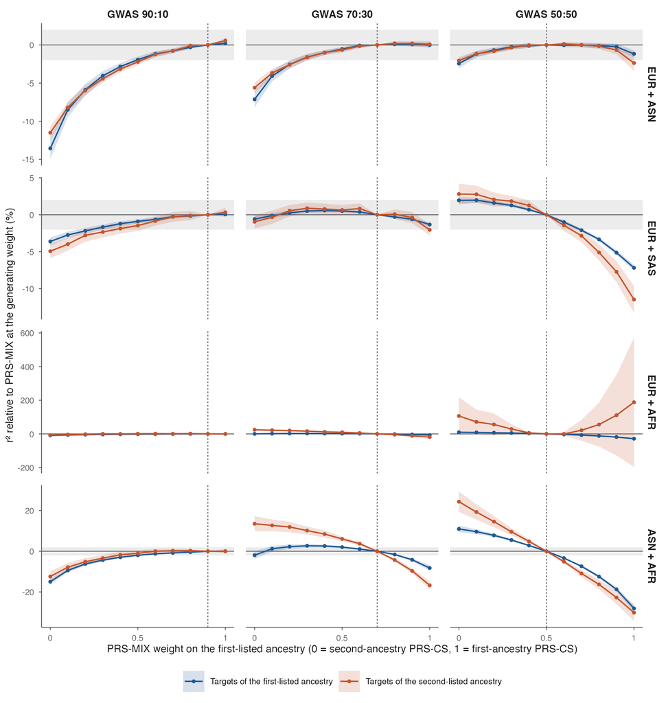

## Figure 2. Mean squared error across weights

Geometric-mean percentage change in MSE against the true genetic value relative to PRS-LDmix at the generating weight, with pointwise 95% intervals; negative is better; grey band ±2%. Free y-axis per row.

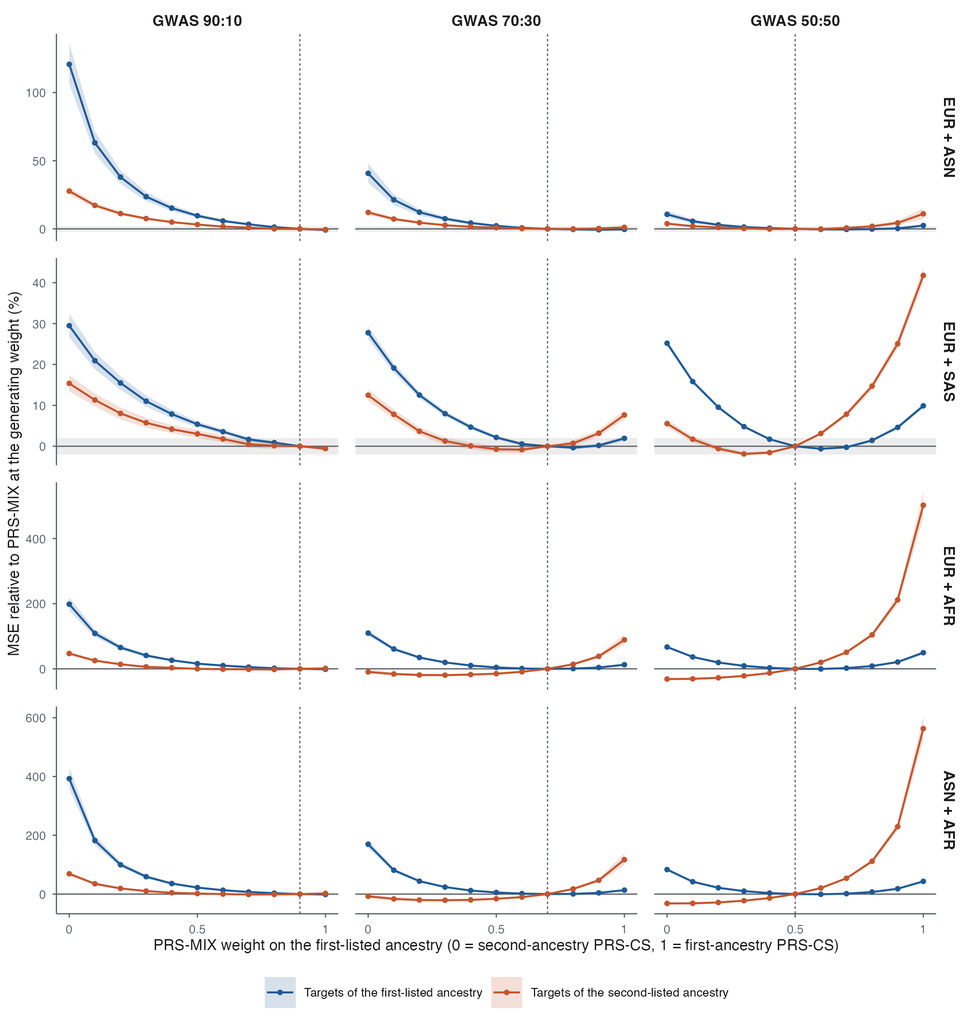